# Data visualization

### Some aesthetics are specific to geom

For example, use `xintercept` for a vertical reference line in `geom_vline()`.

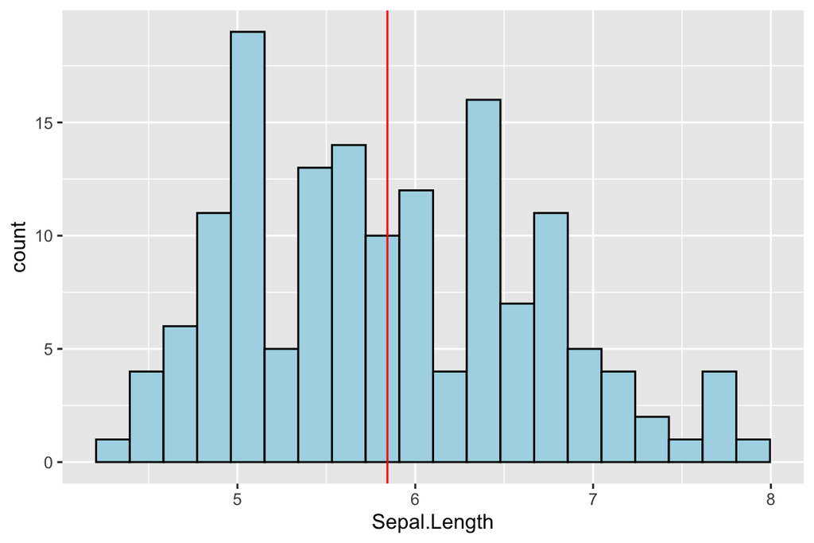

```r
iris_df |>
  ggplot(aes(x = Sepal.Length)) + #aesthetics for all geoms
  geom_histogram(bins = 20,
                 fill = 'lightblue',
                 color = 'black') +
  geom_vline(aes(xintercept = mean(Sepal.Length)), #aesthetics for THIS geom
             color = "red")
```

## Geom variables and aesthetics

> `fill`, `color`, `size`, `shape`, `stroke` and `alpha` can be seen **outside and inside** of `aes()`.

> **These values can also be set to a specific fixed value.**
- Use them inside `aes()` to map variables to visual properties
- Set them outside `aes()` to fix their values
- Each geom requires particular aesthetics, such as x and y **for points.**

### Inside the `aes()`

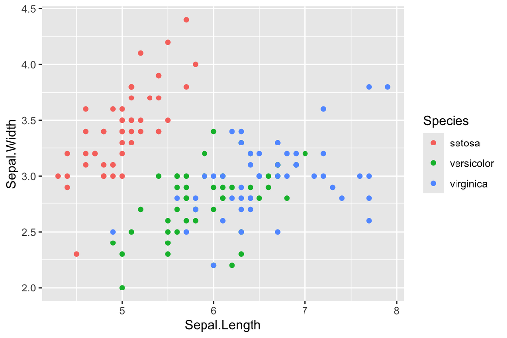

```r
iris_df |>
  ggplot(aes(x = Sepal.Length,
             y = Sepal.Width)) +
  geom_point(aes(color = Species))
```

### Outside the `aes()`

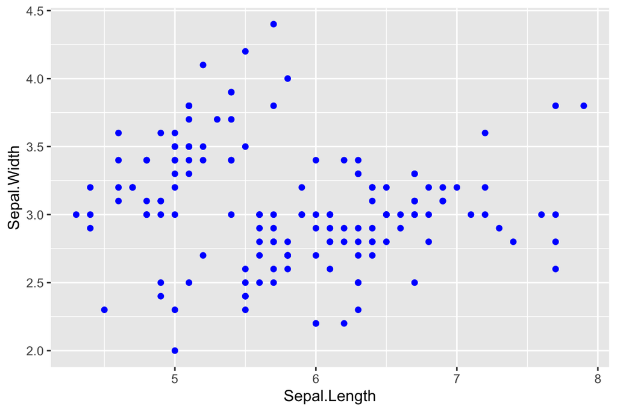

```r
ggplot(data = iris_df,
       mapping = aes(x = Sepal.Length,
                     y = Sepal.Width)) +
  geom_point(color = 'blue')
```

### (not) Blue scatter-plot

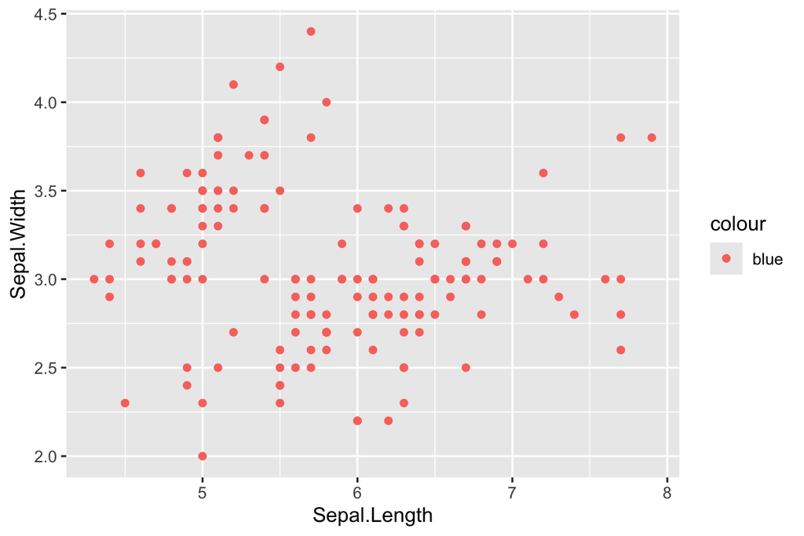

```r
ggplot(data = iris_df,
       mapping = aes(x = Sepal.Length,
                     y = Sepal.Width)) +
  geom_point(aes(color = 'blue'))
```

Inside `aes()`, the string “blue” becomes a category and receives a scale color. Use `color = "blue"` outside `aes()` for a fixed blue color.

## Themes

### Built-in themes

Add a theme to change the overall appearance without changing the data or aesthetic.

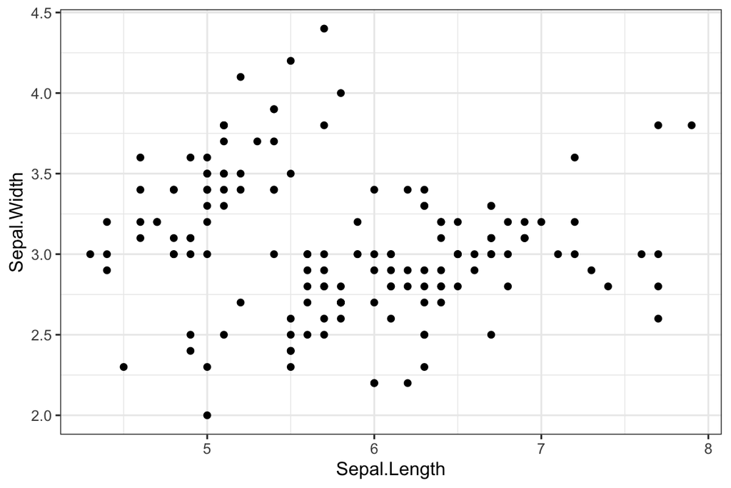

```r
ggplot(data = iris_df,
       mapping = aes(x = Sepal.Length, y = Sepal.Width)) +
  geom_point() +
  theme_bw()
```

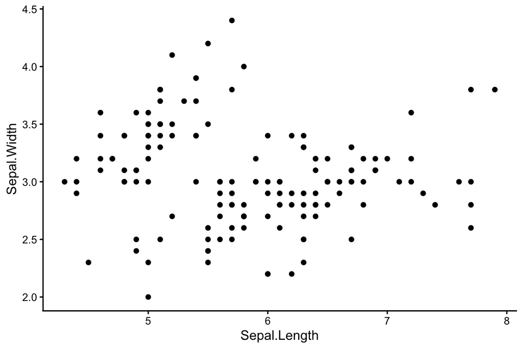

```r
ggplot(data = iris_df,
       mapping = aes(x = Sepal.Length, y = Sepal.Width)) +
  geom_point() +
  theme_classic()
```

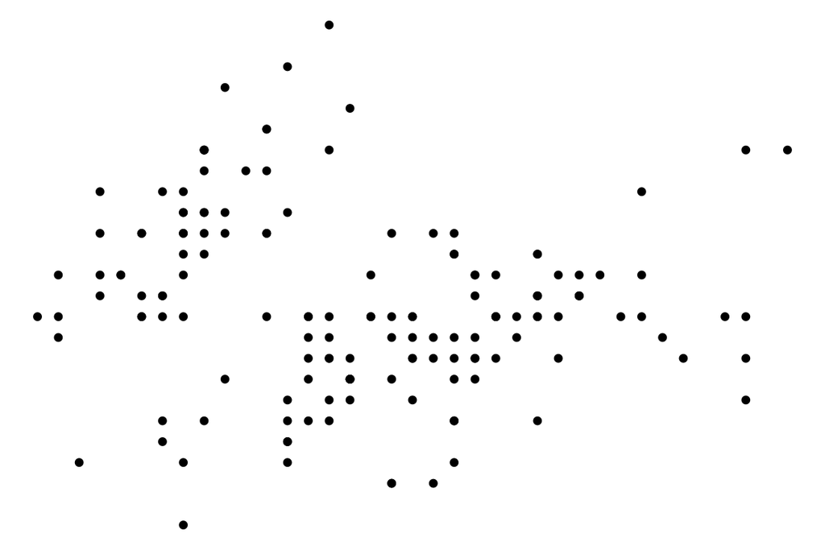

```r
ggplot(data = iris_df,
       mapping = aes(x = Sepal.Length, y = Sepal.Width)) +
  geom_point() +
  theme_void()
```

### Custom themes

Use `theme()` to adjust individual elements.

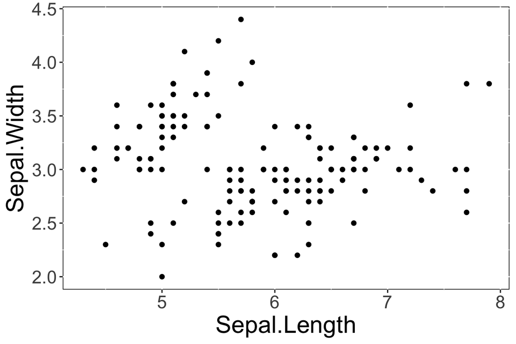

```r
ggplot(data = iris_df,
       mapping = aes(x = Sepal.Length, y = Sepal.Width)) +
  geom_point() +

  theme(axis.text = element_text(size = 15),
          axis.title = element_text(size = 20),
          panel.background = element_rect(fill = 'white', color='black'))
```

### Setting theme for all plots

Use `theme_set()` to apply a default style to subsequent plots. You can combine your settings with a complete theme such as `theme_bw()`.

```r
theme_custom <- theme(
    axis.text = element_text(size = 15),
    axis.title = element_text(size = 20),
    plot.title = element_text(size = 20, hjust = 0.5),
    plot.subtitle = element_text(size = 15, hjust = 0.5),
    legend.title = element_text(size = 15),
    legend.text = element_text(size = 15),
    panel.background = element_rect(fill = "white"),
    panel.grid = element_blank()
  )

theme_set(theme_custom)
```

## Labels

Use `labs()` to name axes and legends, add a title, and explain units or sources in a caption.

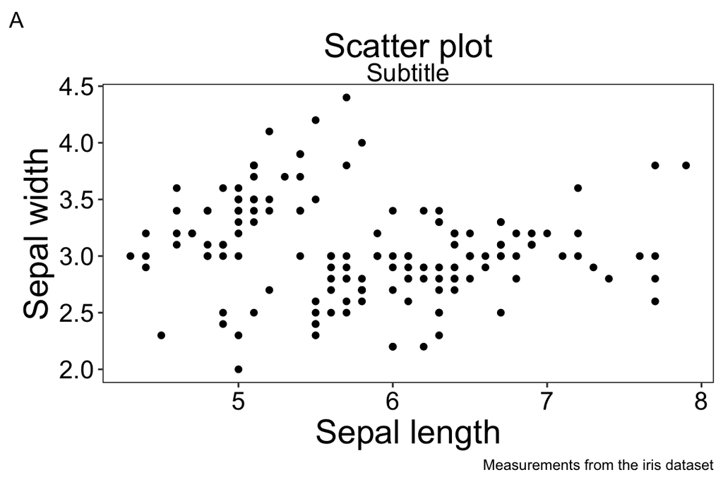

```r
ggplot(data = iris_df,
       mapping = aes(x = Sepal.Length, y = Sepal.Width)) +
  geom_point() +

  labs(x='Sepal length',
          y='Sepal width',

          # color = 'Iris species',
          # fill =
          # size =
          # shape =
          # stroke =

          title = 'Scatter plot',
          subtitle = 'Subtitle',
          caption = 'Measurements from the iris dataset',
          tag = 'A')
```

Simple functions for labeling axes: `+ xlab()` and `+ ylab()`

## Facets

### `facet_wrap()`

Use one grouping variable to create comparable panels.

- `facet_wrap(~ Species)` arranges them in a wrapped layout.

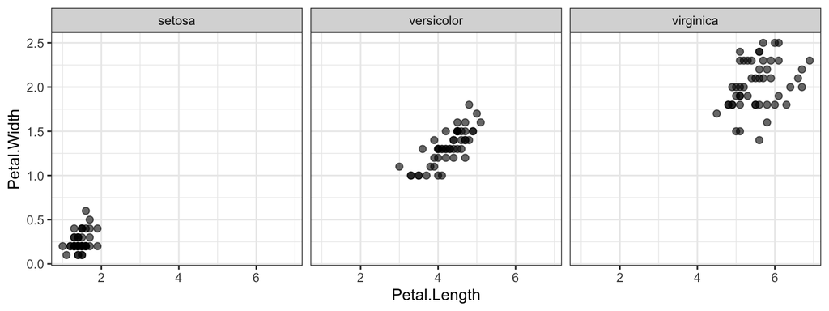

```r
iris_df |> ggplot(aes(x=Petal.Length, y=Petal.Width)) +
  geom_point(alpha=0.6, size=2) +
  theme_bw() +

facet_wrap( ~ Species)
```

### `facet_grid()`

Use row and column variables to create a grid of panels for combinations of two groups.

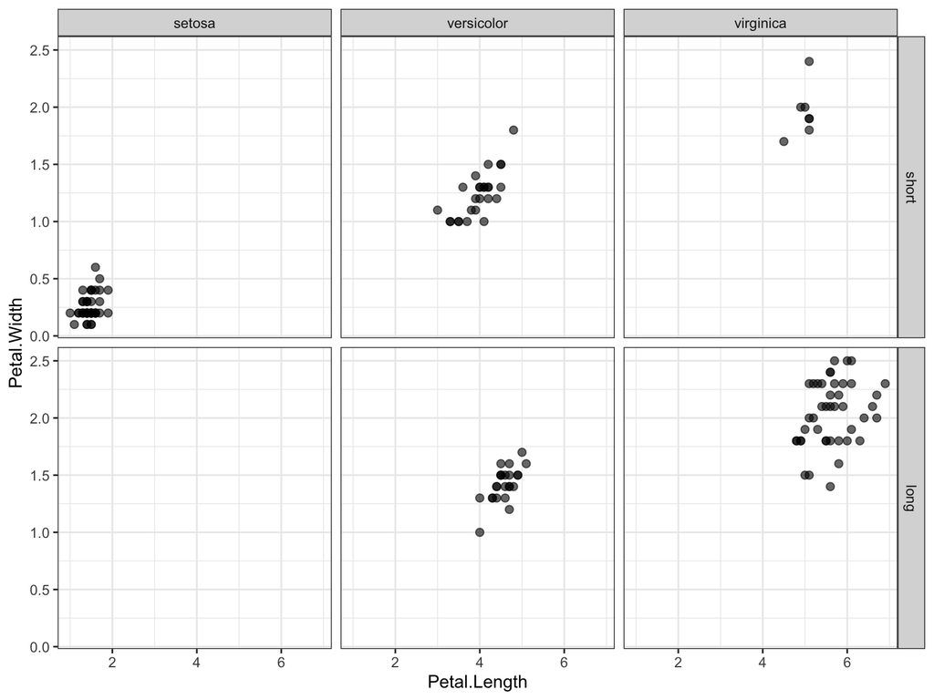

```r
iris_df |> ggplot(aes(x=Petal.Length, y=Petal.Width)) +
  geom_point(alpha=0.6, size=2) +
  theme_bw() +

  facet_grid(cols = vars(Species),
             rows=vars(Sepal.Length.Category))
```

```r
  # facet_wrap(Sepal.Length.Category ~ Species)
```

# Let’s draw!

## Scatter plot

> Draw **scatter-plot** (`geom_point`) with **x=Petal.Length, y=Petal.Width** using classic theme

```r
# Your code here
```

## Histogram

> Draw **histogram** (`geom_histogram`) of **Petal.Length** using *blue* `color` and *lightblue* `fill` and classic theme

```r
# Your code here
```

## Density plot

> Draw **density plot** (`geom_density`) of **Petal.Length** for every Species filled differently + alpha=0.8 and classic theme

```r
# Your code here
```

## Boxplot

> Draw a horizontal **box plot** (`geom_boxplot`) of **Petal.Width** for each species on the y-axis with different fill. Remove legend (why?)

```r
# Your code here
```

> **We can combine custom and built-in themes in one plot!**

### Removing a redundant legend

- `+ theme(legend.position = "none")`

# Kinds of diagrams

| Question | Variables | Suggested plot |
| --- | --- | --- |
| How many observations are in each category? | One categorical | `geom_bar()` |
| How is a variable distributed? | One numeric | `geom_histogram()`, `geom_density()` |
| How do distributions differ across groups? | Numeric + categorical | `geom_boxplot()`, `geom_jitter()`, `geom_violin()` |
| Are two numeric variables related? | Two numeric | `geom_point()` |
| Are two categorical variables associated? | Two categorical | `geom_bar(position = "fill")`, `geom_count()` |
| Does a relationship differ across groups? | Two numeric + categorical | Color or facets |

## Barplot

```r
sepal_len_stats <- iris_df |> group_by(Species) |>
  summarise(
    mean_sepal_len = mean(Sepal.Length),
    sd_sepal_length = sd(Sepal.Length)
  )

sepal_len_stats
```

```
# A tibble: 3 × 3
  Species    mean_sepal_len sd_sepal_length
  <fct>               <dbl>           <dbl>
1 setosa               5.01           0.352
2 versicolor           5.94           0.516
3 virginica            6.59           0.636
```

### `geom_col()` uses supplied Y values

> Draw a **barplot** (`geom_col`) of **mean_sepal_len** for each species on the x-axis with different fill. Remove legend.

```r
# Your code here
```

### Adding `geom_errorbar` (SD)

These bars show mean ± SD: variation among observations, not uncertainty in the mean. Always label the type of error bar.

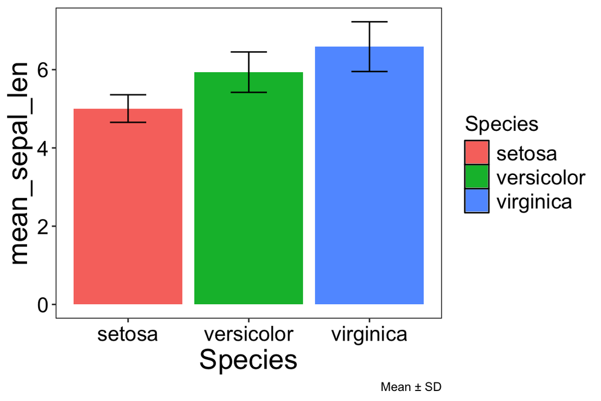

```r
ggplot(sepal_len_stats, aes(x = Species,
                            y = mean_sepal_len)) +
  geom_col(aes(fill = Species)) +
  geom_errorbar(
    aes(
      ymin = mean_sepal_len - sd_sepal_length,
      ymax = mean_sepal_len + sd_sepal_length
    ),
    width = 0.3
  ) +
  labs(caption = "Mean ± SD")
```

> Three different types of values are commonly used for error bars, *sometimes without even specifying which one is used*.
> - **Standard deviation**
> - **Standard error**
> - **Confidence interval**

> We will discuss each later

### `geom_bar()` counts rows in each category

> Draw a **barplot** (`geom_bar`) of **Sepal.Length.Category** (x-axis and fill).

```r
# Your code here
```

#### `position="stack"` (by default)

Stack counts to show both category totals and their composition.

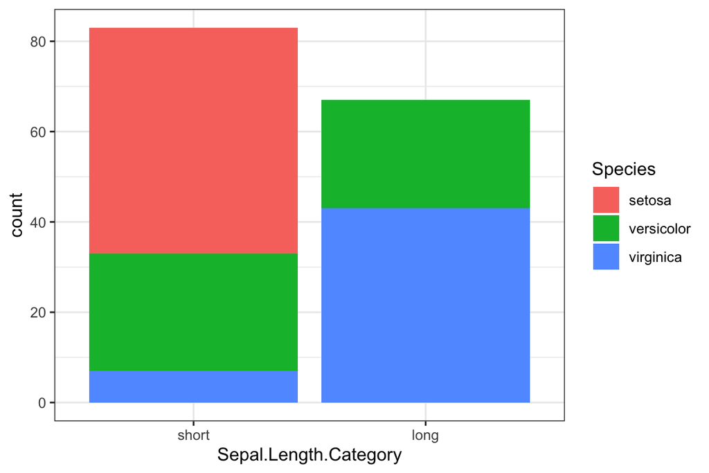

```r
iris_df |>
  ggplot(aes(x=Sepal.Length.Category, fill=Species)) +
  geom_bar() +
  theme_bw()
```

#### `position="fill"` - scaled from 0 to 1

Normalize each stack to 1 to compare group proportions rather than counts.

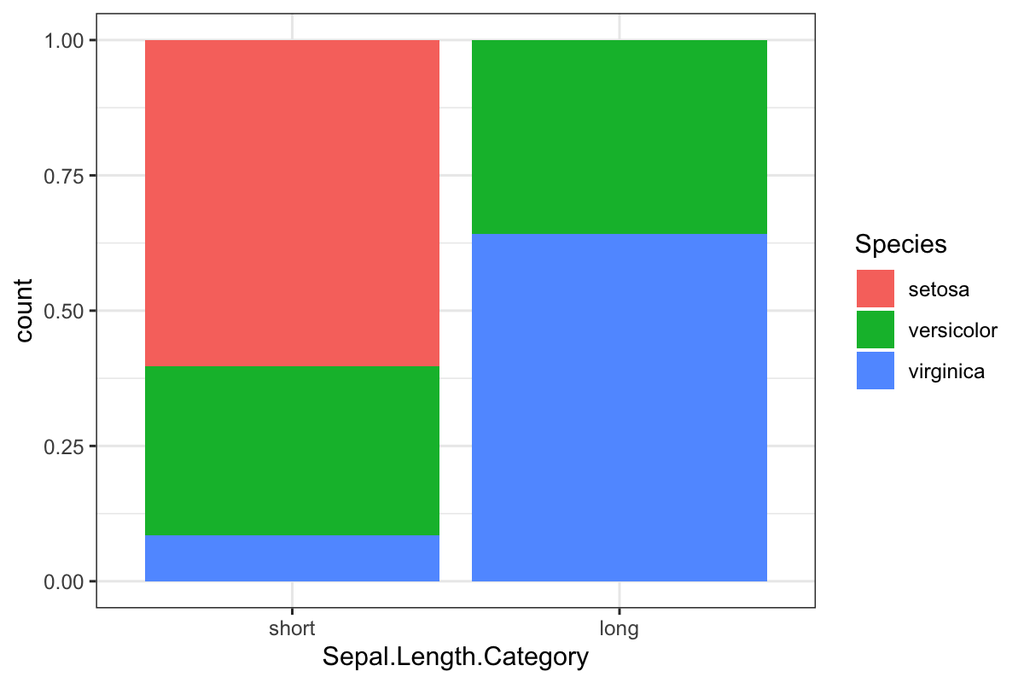

```r
iris_df |> ggplot(aes(fill = Species, x = Sepal.Length.Category)) +
  geom_bar(position = 'fill') +
  theme_bw()
```

#### `position="dodge"`

Place bars side by side to compare counts directly across groups.

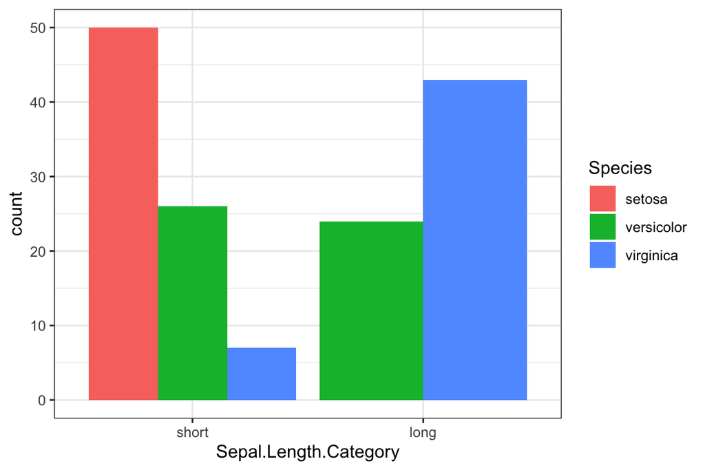

```r
iris_df |>
  ggplot(aes(fill=Species, x=Sepal.Length.Category)) +
  geom_bar(position = 'dodge')  +
  theme_bw()
```

## Pie chart

To make a pie chart, stack counts in a single bar and use `coord_radial(theta = "y")` to turn bar heights into angles. Use it for simple part-to-whole comparisons.

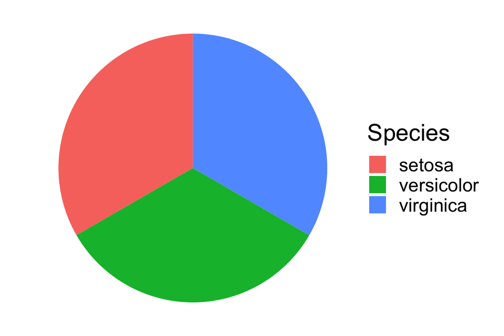

```r
iris_df |>
  ggplot(aes(x = "", fill = Species)) +
  geom_bar(width = 1) +

  coord_radial(theta = "y", expand = FALSE) + # <---

  labs(x = NULL, y = NULL) +
  theme_void(base_size = 20)
```

## Boxplot + jitter plot

Combine the boxplot summary with individual observations.

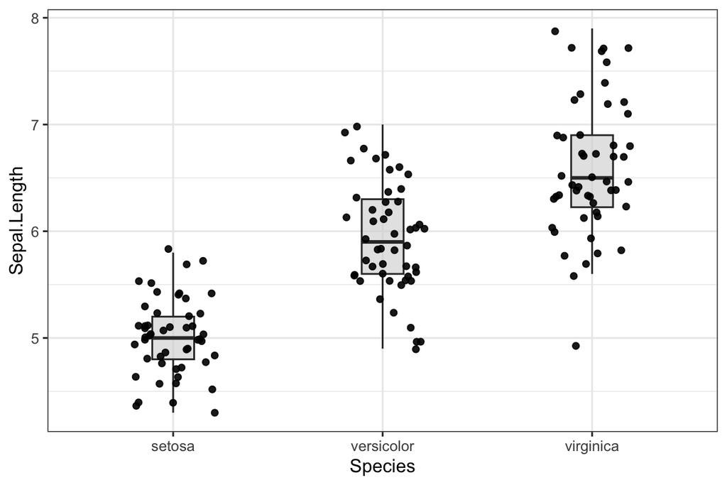

```r
iris_df |>
  ggplot(aes(x = Species, y = Sepal.Length)) +
  geom_boxplot(fill = "lightgray", alpha = 0.6, outliers = FALSE, width = 0.2) +
  geom_jitter(width = 0.2,  alpha = 0.9, shape = 19, col = 'black')  +
  theme_bw() +
  theme(legend.position = 'none')
```

## Dumbbell plot

Compare two category means within each species: summarize first, connect means with `group = Species`.

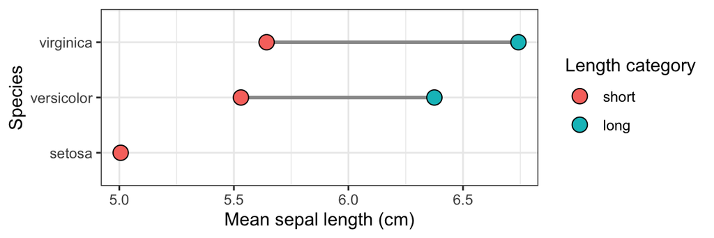

```r
iris_df |>
  group_by(Species, Sepal.Length.Category) |>
  summarise(mean_length = mean(Sepal.Length), .groups = "drop") |>
  ggplot(aes(x = mean_length, y = Species)) +
  geom_line(aes(group = Species), orientation = "y",
            colour = "grey60",
            linewidth = 1) +
  geom_point(aes(fill = Sepal.Length.Category),
             shape = 21,
             size = 4) +
  labs(x = 'Mean sepal length (cm)', fill = 'Length category') +
  theme_bw()
```

## Something big and difficult

Combine distribution shape, individual points, a reference mean, and a one-row dataset for a single label.

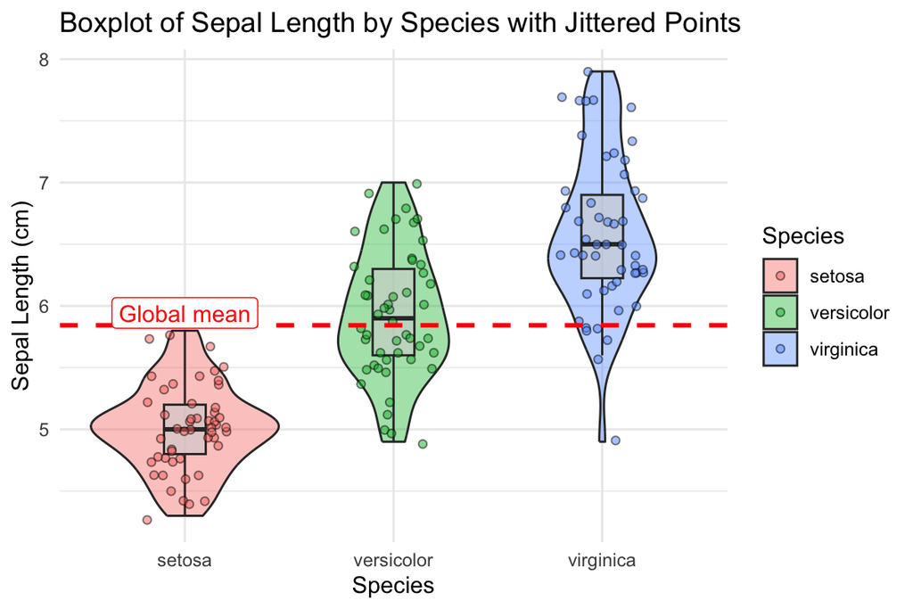

```r
ggplot(iris, aes(x = Species, y = Sepal.Length)) +
  geom_violin(aes(fill = Species), alpha = 0.4) +  # Violin plots
  geom_boxplot(fill = "lightgray", alpha = 0.6, outliers = FALSE, width=0.2) +
  geom_jitter(aes(fill = Species), width = 0.2,  alpha = 0.5, shape=21, col='black') +
  geom_hline(aes(yintercept = mean(Sepal.Length)), col='red', linewidth=1, lty=2) +
  geom_label(data = data.frame(x = "setosa", y = mean(iris$Sepal.Length) + 0.1),
             aes(x = x, y = y, label = "Global mean"),
             inherit.aes = FALSE, color = "red") +
  labs(title = "Boxplot of Sepal Length by Species with Jittered Points",
       x = "Species",
       y = "Sepal Length (cm)") +
  theme_minimal()
```

### New geoms used

- `geom_violin()` shows a smoothed distribution
- `geom_hline()` adds a horizontal reference line using `yintercept`.
  - `geom_vline()` adds a vertical reference line using `xintercept`.
- `geom_text()` draws text at `x` and `y` using the `label` aesthetic.
  - `geom_label()` adds a background box.

# Plot arranging

## Storing plots in variables

Assign a plot to a variable, then print or extend it with `+` to reuse it.

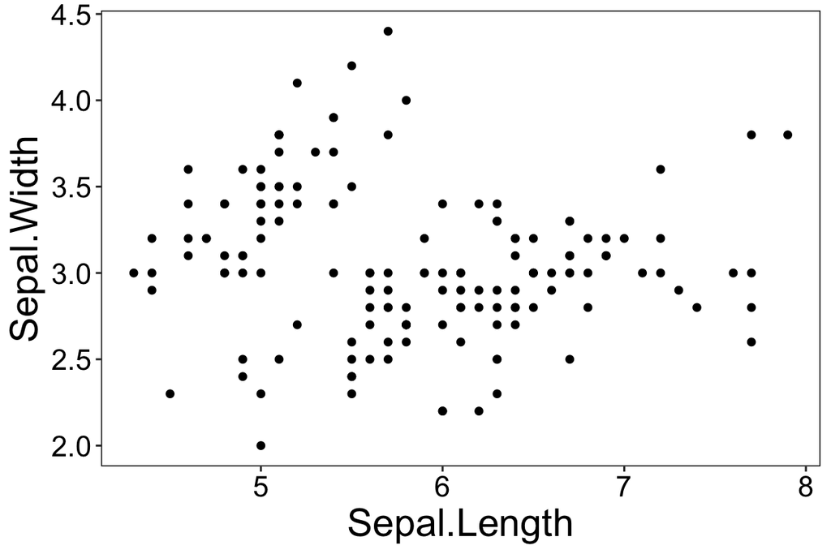

```r
p <- ggplot(data = iris_df,
            mapping = aes(x = Sepal.Length, y = Sepal.Width)) + geom_point()

p
```

## **`patchwork`**

```r
library(patchwork)
```

Use `patchwork` to combine saved plots:

- `|` places them side by side
- `/` stacks rows
- `()` control grouping.

```r
bar_stack <- iris_df |>
  ggplot(aes(x=Sepal.Length.Category, fill=Species)) +
  geom_bar() +
  theme_bw()

bar_fill <- iris_df |>
  ggplot(aes(fill=Species, x=Sepal.Length.Category)) +
  geom_bar(position = 'fill') + theme_bw()

bar_dodge <- iris_df |>
  ggplot(aes(fill=Species, x=Sepal.Length.Category)) +
  geom_bar(position = 'dodge')  +
  theme_bw()
```

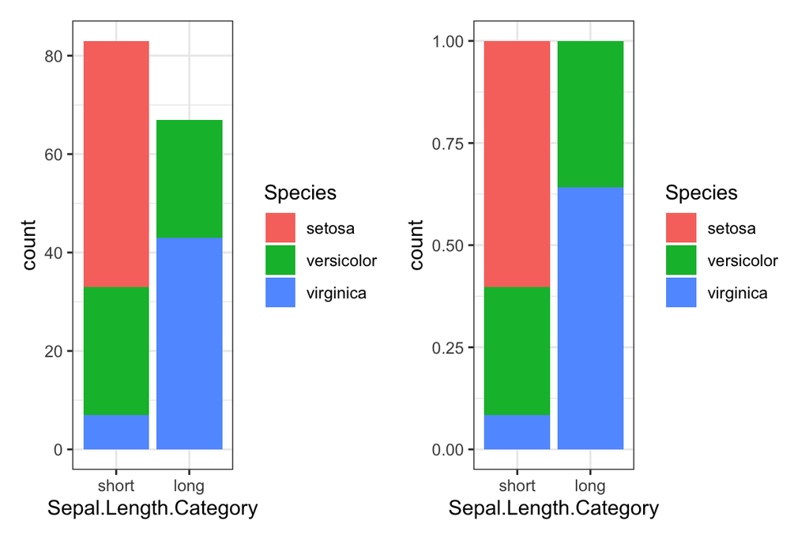

```r
bar_stack + bar_fill
```

### Collect axes and legends

Use `guides = "collect"` to share matching legends. `axes = "collect"` merges matching axes. Use `plot_annotation()` to label panels.

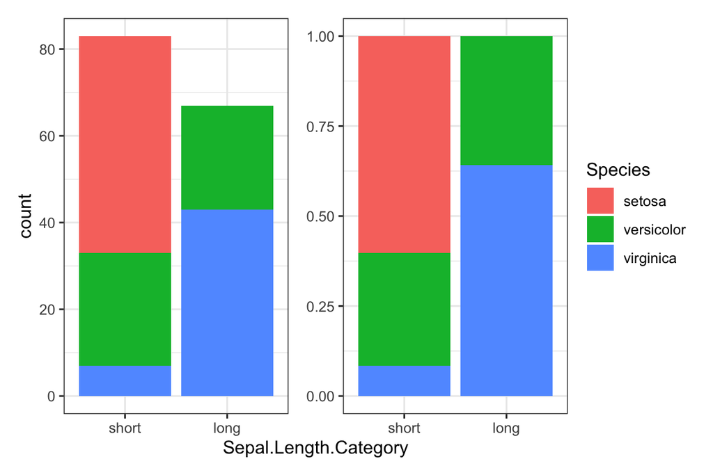

```r
bar_stack + bar_fill +
  plot_layout(guides = 'collect',
              axes = 'collect')
```

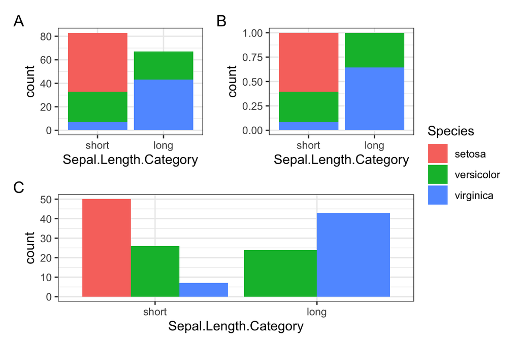

```r
(bar_stack | bar_fill) / bar_dodge +

  plot_layout(guides = 'collect') +
  plot_annotation(tag_levels = 'A')
```

## Saving the plot

### Save a selected plot:

Pass the plot object to `ggsave(plot = ...)`, set dimensions and units for export.

```r
ggsave(
  plot = bar_stack,
  filename = './bigplot.png', # specify the filename (path to file)
  device = 'png', # png, pdf, jpeg, svg and others
  dpi = 300, # resolution
  width = 1800,
  height = 1600,
  units = "px" #in, cm, mm
)
```

### Save “everything between”

Open a PDF “device”, draw plots, and close it with `dev.off()`.

Inside loops or functions, use `print()` to draw ggplot objects.

```r
pdf("./dodge_barplot.pdf", width = 6, height = 6)

iris_df |>
  ggplot(aes(fill=Species, x=Sepal.Length.Category)) +
  geom_bar(position = 'dodge')

dev.off()
```

All plots drawn between `pdf()` and `dev.off()` are saved to the PDF.

# P.S.

## ggpubr (Advanced)

An example of another visualization package. The statistical annotations below are a preview. Choosing tests and interpreting p-values will be covered later.

```r
# install.packages('ggpubr')
library(ggpubr)
```

### Barplot

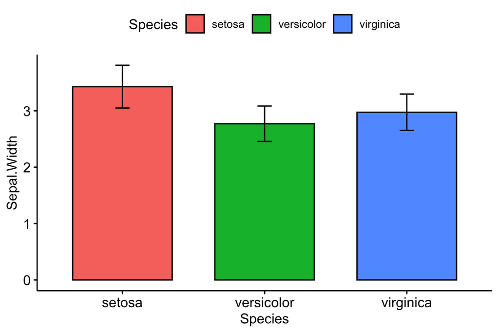

```r
iris_df |>  ggbarplot(x="Species", y="Sepal.Width",
                       fill='Species',
                       add = "mean_sd" # calculate mean and sd
                       )
```

### Boxplot

Statistics inside!

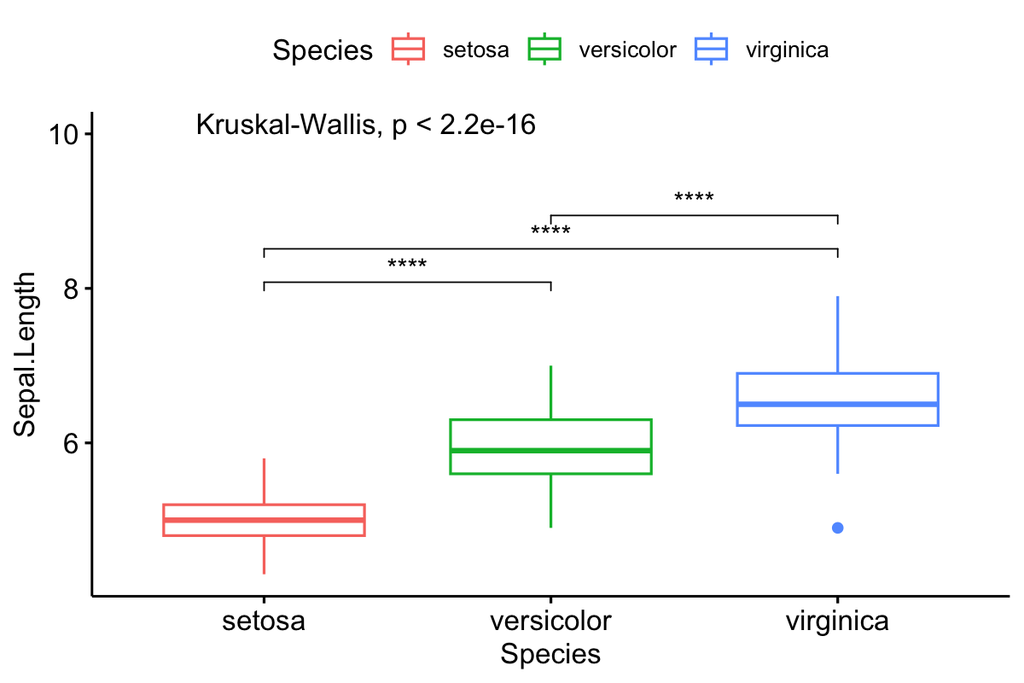

```r
p_pubr <- iris_df |>  ggboxplot(x='Species', y='Sepal.Length', col='Species')

comparisons <- list( c("setosa", "versicolor"),
                     c("setosa", "virginica"),
                     c("virginica", "versicolor") )

p_pubr + stat_compare_means(comparisons = comparisons,
                            label = "p.signif")+
  stat_compare_means(label.y = 10)
```

See more about `ggpubr` [**HERE**](https://rpkgs.datanovia.com/ggpubr/)

## Customizing `fill` - `scale_fill_manual()`

Use `values` to choose category fill colors and `labels` to rename legend entries.

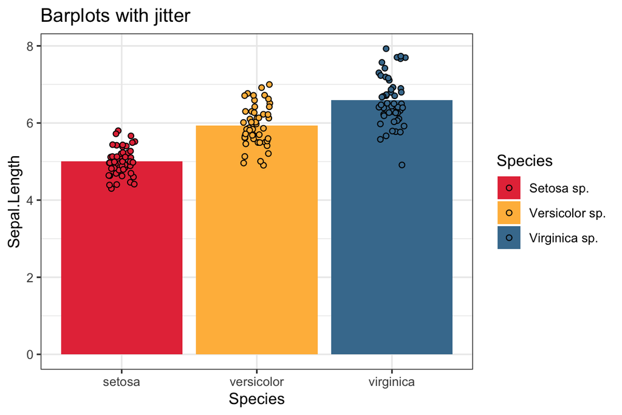

```r
# Advanced -------
iris_df |> ggplot(aes(x=Species, y=Sepal.Length)) +
  stat_summary(aes(fill=Species), geom = 'bar', fun = mean) +
  geom_jitter(aes(fill=Species), shape=21, width = 0.1,
              stroke=0.5, col='black') +
  theme_bw() +
  labs(title = 'Barplots with jitter') +
# ----------

scale_fill_manual(
  values=c("#e63946", "#ffba49", "#457b9d"),
  labels=c('Setosa sp.', 'Versicolor sp.', 'Virginica sp.'),
)
```

## Customizing `color` - `scale_color_manual()`

Use a manual color scale for point or line colors. Use the fill scale separately for filled areas.

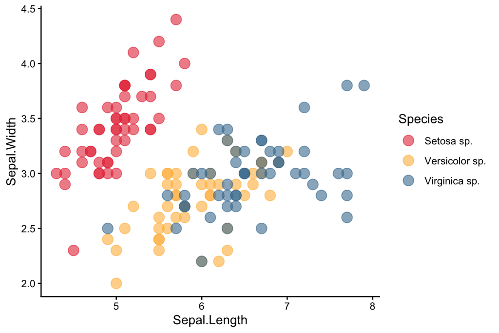

```r
iris_df |> ggplot(aes(x=Sepal.Length, y=Sepal.Width, col=Species)) +
  geom_point(alpha=0.6, size=4) +
  theme_classic() +

scale_color_manual(
  values=c("#e63946", "#ffba49", "#457b9d"),
  labels=c('Setosa sp.', 'Versicolor sp.', 'Virginica sp.'),
)
```